# Results of Thesis

## The Functional Preference of Policemen when Using a Reflection Machine in Preventive Frisking

This is a notebook containing the results of the thesis of Hannah Venhuizen studying Artificial Intelligence at the Radboud University. In this thesis, an experiment took place in which nine students and five policemen participated. It contains both the data of the output of an application used in this thesis and a survey filled in twice by each participant.

```python
import numpy as np
import matplotlib.pyplot as plt
import pandas as pd
from tabulate import tabulate
```

## Research setup

The research setup is defined into two parts. In one part, the focus is on the TYPE of questions/notifications (from now on called part A). In the other part, the focus is on the FREQUENCY with which a questions/notifications is posed (from now on called part B). All participants participate in each part. However, these parts can be presented in two different orders:

- type (A) -> frequency (B) or;
- frequency (B) -> type (A)

After each part, a survey is filled out with questions about the experiment. Part A consists of three blocks and part B consists of two blocks. Every block contains 4 cases. If you want to know more details, I refer you to the written thesis.

For now, it is important to stress again that there are two different sets of data for every participant. One is of the application, the other of the surveys. Section 1. Survey is both about the student and the policemen data.

# 1. Survey

In the next section we will focus on the Survey data.

Below, we load the data and some helpful functions. You do not need to understand the code cells.

```python
# --- STUDENTS ---
# informed about DSS
sp6 = np.array([[3,2,2,3,4,3,3,2],[2,3,2,3,5,3,3,3],[3,2,2,4,4,4,3,2]]) # a1
sp7 = np.array([[2,4,3,4,2,2,3,4],[2,4,3,3,3,3,4,4],[2,2,3,3,2,3,2,2]]) # a1
sp3 = np.array([[3,4,2,4,4,4,1,5],[3,4,3,4,5,3,1,4],[3,4,3,3,5,3,2,2]]) # a2
sp0 = np.array([[3,4,3,4,5,4,4,5],[4,4,3,4,4,4,3,4],[3,3,2,4,4,4,4,4]]) # a2
s_dss = np.array([sp6, sp7, sp3, sp0])
s_dss_labels = np.array(['sp6 (A->B)','sp7 (A->B)','sp3 (B->A)','sp0 (B->A)'])

# not informed about DSS
sp2 = np.array([[4,1,4,4,-1,2,5,2],[3,2,2,3,-1,4,5,1],[4,1,4,4,-1,3,4,4]]) # b1
sp5 = np.array([[3,2,2,3,-1,3,3,3],[3,2,3,4,-1,4,3,4],[2,3,3,4,-1,3,3,3]]) # b1
sp8 = np.array([[4,1,3,3,-1,2,1,2],[3,3,3,4,-1,2,1,4],[4,2,3,3,-1,3,3,4]]) # b1
sp1 = np.array([[3,2,4,5,-1,5,1,4],[3,3,5,5,-1,5,1,4],[4,2,5,5,-1,5,3,4]]) # b2
sp4 = np.array([[4,3,3,3,-1,4,2,4],[4,4,4,3,-1,4,2,4],[3,3,4,3,-1,4,3,4]]) # b2
s_no_dss = np.array([sp2, sp5, sp8, sp1, sp4])
s_no_dss_labels = np.array(['sp2 (A->B)', 'sp5 (A->B)', 'sp8 (A->B)', 'sp1 (B->A)', 'sp4 (B->A)'])

# all student participants together
sps = np.array([sp0,sp1,sp2,sp3,sp4,sp5,sp6,sp7,sp8])
sps_labels = np.array(['sp0 (B->A)','sp1 (B->A)','sp2 (A->B)','sp3 (B->A)','sp4 (B->A)','sp5 (A->B)','sp6 (A->B)','sp7 (A->B)','sp8 (A->B)'])

# --- POLICE ---
# informed about DSS
pp3 = np.array([[1,2,1,3,2,4,1,3],[2,1,1,3,3,4,1,3]]) # a1
pp2 = np.array([[3,1,3,3,1,5,1,5],[3,1,3,3,4,4,1,5]]) # a2
pp1 = np.array([[3,2,4,2,4,4,1,3],[3,2,4,2,3,4,2,2]]) # a2
p_dss = np.array([pp3,pp2,pp1])
p_dss_labels = np.array(['pp3 (A->B)','pp2 (B->A)','pp1 (B->A)'])

# NOT informed about DSS
pp0 = np.array([[4,1,5,1,-1,2,2,1],[4,1,4,2,-1,4,2,4]]) # b2
pp4 = np.array([[2,3,2,3,-1,3,1,3],[2,3,2,3,-1,3,1,4]]) # b1
p_no_dss = np.array([pp0,pp4])
p_no_dss_labels = np.array(['pp0 (B->A)','pp4 (A->B)'])

# all police participants together
pps = np.array([pp0,pp1,pp2,pp3,pp4])
pps_labels = np.array(['pp0 (B->A)','pp1 (B->A)','pp2 (B->A)','pp3 (A->B)','pp4 (A->B)'])


# --- STATEMENT 9: RANKED RELEVANCE ---
# Answer to statement 9. Ranked order of relevance (1 being most relevant, 8 being least relevant)
students = np.array([[1,2,6,4,5,8,3,7], [2,1,5,6,8,3,4,7], [2,4,6,7,5,1,3,8], [1,5,2,7,4,6,8,3],[2,1,6,8,5,7,3,4], [8,7,5,6,2,3,1,4], [2,1,3,5,8,4,6,7],[7,8,6,4,5,2,3,1],[3,1,4,6,2,7,5,8]])
police = np.array([[3,4,5,6,1,2,8,7], [3,4,2,7,1,5,8,6], [3,5,6,7,8,4,2,1], [2,6,1,7,8,5,4,3], [3,5,6,7,8,4,2,1]])

# Translate the order to scores (7 being most relevant, 0 being least relevant)
students = 8-students
police = 8-police
```

Below, we define a function which helps us put the ranking numbers into the actual ranking values.

```python
# a function which transforms the ratings to actual answers
def transform(a, indicator,participant=-1,student=False, labels=False, number=0):
    indicator+=1
    s = ""
    lala=["","","","","","","","","",""]
    if number==1:
        if student==True:
            lala=s_dss_labels
        else: lala=p_dss_labels
    if number==2:
        if student==True:
            lala=s_no_dss_labels
        else:
            lala=p_no_dss_labels
    if participant!=-1:
        s = "Participant " + str(participant) + " "
    agree = ["Strongly disagree; ", "Disagree; ", "Neutral; ", "Agree; ", "Strongly agree; "]
    amount = ["The less the better; ", "Neutral; ", "The more the better; "]
    student_amount = ["The less the better; ", "I like less; ", "Neutral; ", "I like more; ", "The more the better; "]
    quality = ["Very bad; ", "Bad; ", "Neutral; ", "Good; ", "Very good; "]
    counter=0
    for i in a:
        s+=lala[counter]
        counter+=1
        i = int(round(i))
        if indicator<4 or indicator==5 or indicator>6:
            if i != -1:
                lab=agree
                s+=agree[i-1]
        elif indicator==4:
            if student:
                lab=student_amount
                s+=student_amount[i-1]
            else:
                lab=amount
                s+=amount[i-1]
        elif indicator==6:
            lab=quality
            s+=quality[i-1]

    if labels==True:
        return lab
    return s
```

```python
def statements(statnr, participant='police', dss=0):
    s_A=[s_surveyA, s_surveyA_dss, s_surveyA_no_dss]
    s_B=[s_surveyB, s_surveyB_dss, s_surveyB_no_dss]
    s_C=[s_surveyC, s_surveyC_dss, s_surveyC_no_dss]
    info=["","Informed about the DSS", "NOT informed about the dss"]

    if dss==0:
        if participant=='police':
            stat=[[pps_labels[i], transform([p_surveyA[:,statnr][i]],statnr), transform([p_surveyB[:,statnr][i]],statnr)] for i in range(len(pps))]
            table=[['Participants', 'Survey part A', 'Survey part B'], stat[0], stat[1], stat[2], stat[3], stat[4]]
        else:
            stat=[[sps_labels[i], transform([s_surveyA[:,statnr][i]],statnr, student=True), transform([s_surveyB[:,statnr][i]],statnr, student=True)] for i in range(len(sps))]
            table=[['Participants', 'Survey part A', 'Survey part B'], stat[0], stat[1], stat[2], stat[3], stat[4], stat[5],stat[6],stat[7],stat[8]]
    elif dss==1:
        if participant=='police':
            stat=[[p_dss_labels[i], transform([p_surveyA_dss[:,statnr][i]],statnr), transform([p_surveyB_dss[:,statnr][i]],statnr)] for i in range(len(p_dss))]
            table=[['Participants', 'Survey part A', 'Survey part B'], stat[0], stat[1], stat[2]]
        else:
            stat=[[s_dss_labels[i], transform([s_surveyA_dss[:,statnr][i]],statnr, student=True), transform([s_surveyB_dss[:,statnr][i]],statnr, student=True)] for i in range(len(s_dss))]
            table=[['Participants', 'Survey part A', 'Survey part B'], stat[0], stat[1], stat[2], stat[3]]
    else:
        if participant=='police':
            stat=[[p_no_dss_labels[i], transform([p_surveyA_no_dss[:,statnr][i]],statnr), transform([p_surveyB_no_dss[:,statnr][i]],statnr)] for i in range(len(p_no_dss))]
            table=[['Participants', 'Survey part A', 'Survey part B'], stat[0], stat[1]]
        else:
            stat=[[s_no_dss_labels[i], transform([s_surveyA_no_dss[:,statnr][i]],statnr, student=True), transform([s_surveyB_no_dss[:,statnr][i]],statnr, student=True)] for i in range(len(s_no_dss))]
            table=[['Participants', 'Survey part A', 'Survey part B'], stat[0], stat[1], stat[2], stat[3], stat[4]]

    print(">>> ", info[dss] ,"\nSurvey Question: '",
              qs[statnr],"\n")
    print(tabulate(table, headers='firstrow'))
```

```python
def statement(i, participant='police', dss=0):
    s_A=[s_surveyA, s_surveyA_dss, s_surveyA_no_dss]
    s_B=[s_surveyB, s_surveyB_dss, s_surveyB_no_dss]
    s_C=[s_surveyC, s_surveyC_dss, s_surveyC_no_dss]

    p_A=[p_surveyA, p_surveyA_dss, p_surveyA_no_dss]
    p_B=[p_surveyB, p_surveyB_dss, p_surveyB_no_dss]
    if participant == 'students':
        statement_plot((s_A[1])[:,i],(s_A[2])[:,i],transform((s_A[dss])[:,i], i,student=True, labels=True),i, st='students')
        statement_plot((s_B[1])[:,i],(s_B[2])[:,i],transform((s_B[dss])[:,i], i,student=True, labels=True),i, part=1, st='students')

    else:
        statement_plot((p_A[1])[:,i],(p_A[2])[:,i],transform((p_A[dss])[:,i], i, labels=True),i)
        statement_plot((p_B[1])[:,i],(p_B[2])[:,i],transform((p_B[dss])[:,i], i, labels=True),i, part=1)
```

```python
def statement_plot(info, not_info, labels, q, part=0, st='police'):
    y='The amount of ' + st
    x='Rates given by ' + st
    if part==0:
        title=qs[q] + ' Survey part A'
    else:
        title=qs[q] + ' Survey part B'
    dss=np.array([])
    nodss=np.array([])
    for i in range(len(labels)):
        dss=np.append(dss,np.count_nonzero(info == i+1))
        nodss=np.append(nodss,np.count_nonzero(not_info == i+1))
    width = 0.35
    fig = plt.figure()
    ax = fig.add_axes([0,0,1,1])
    ax.bar(labels, dss, width, color='r')
    ax.bar(labels, nodss, width,bottom=dss, color='b')
    ax.set_yticks(np.arange(0, 6, 1))
    ax.legend(labels=['DSS informed', 'not informed'])
    ax.set_ylabel(y)
    ax.set_xlabel(x)
    ax.set_title(title)
    plt.show()
```

## 1.0 Sub-questions

Three sub-questions can be answered with use of the data from the surveys. The questions are:

1. **What type of reflective questions/notifications do policemen prefer?**
2. **How often should the RM pose a reflective question/notification?**
3. **Does the experience of interacting with a DSS influence the experience of the RM?**

Half of the participants is (falsely) informed that a Decision Support System (DSS) is included, where the individuals in the videos are selected by an algorithm. The other half of the participants is (truly) informed that we selected the individuals randomly out of the videos, so without help of a DSS.

We questioned the participants in a survey after each part (A and B). The surveys include statements about the application, where the participants responded by giving a ranking. The statements are as follows (where some aspects of the questions depend on the DSS condition: e.g. "I think the selection made by the algorithm is very accurate"):

```python
qs = np.array(["I think the selection made (by the algorithm) is very accurate","After a reflective question/notification I actively reconsider my decision about the frisking", "I would have picked the same individuals as the algorithm", "How do you experience the amount of reflective questions and notifications?", "I think the concept of the algorithm could be helpful in the field of preventive frisking", "How do you experience the quality of the reflective questions and notifications?", "I felt criticized by the reflective questions and notifications" ,"The reflective question or notification helped me think about potential bias", "You saw the following reflective questions / notifications. Please rank them in order of relevance."])
print(np.array([str(i+1) + ". " + qs[i] for i in range(len(qs))]))
```

```
['1. I think the selection made (by the algorithm) is very accurate'
 '2. After a reflective question/notification I actively reconsider my decision about the frisking'
 '3. I would have picked the same individuals as the algorithm'
 '4. How do you experience the amount of reflective questions and notifications?'
 '5. I think the concept of the algorithm could be helpful in the field of preventive frisking'
 '6. How do you experience the quality of the reflective questions and notifications?'
 '7. I felt criticized by the reflective questions and notifications'
 '8. The reflective question or notification helped me think about potential bias'
 '9. You saw the following reflective questions / notifications. Please rank them in order of relevance.']
```

## 1.1 What type of reflective questions/notifications do participants prefer?

We will answer this sub-question for both students and policemen. In order to do that, we analyze statement 9: *"You saw the following reflective questions / notifications. Please rank them in order of relevance."*

This statement is only presented in the survey after the participant completed block 1. So every participant answered this statement exactly once. The questions which need to be ranked are:

- C1 Are you sure about your decision (not) to frisk this person? Why (not)?
- C2 How certain are you about your decision (not) to frisk this person? Why?
- C3 Are you sure your focus will lead to an optimal decision? Why (not)?
- P1 Consider that [X] % of all people of the population walking past this spot [...]
- P2 Do you think this person deviates from the population in a particular aspect? Why (not)?
- P3 Consider that [X] % of all weapons carriers of this population [...]
- H1 Up to now, you have decided (not) to frisk [X] % of all the people presented to you
- H2 Consider that [X] % of all the people you decided (not) to frisk up to now [...]

Where C, P, H mean Certainty based, Population based an History based respectively. The 1, 2, and 3 are the indicators of the instance of that type. Of course, the labels are not presented to the participant. Before we begin, we load the data:

```python
# Type of questions
labels = ["C1","C2","C3","P1","P2","P3","H1","H2"]
labels_CPH = ["C", "P", "H"]

# Total number of instances of types
N = 8
```

The questions are given a score with respect to how much the student experienced it a relevant intervention. The most relevant is scored by 7 points, while the least relevant is scored by 0 points with in between steps of 1 (i.e. 7, 6, 5,...,0).

### 1.1.1 Relevance ranked by students

Now let us make a list of all types of questions presented to the students coupled with the averaged score given by the students.

```python
# scores of student participants with the following order: c1,c2,c3,p1,p2,p3,h1,h2
scores_s= np.array([])

# standard deviations across student participants
stds_s= []

# for each question
for i in range(0,N):
    # append the standard deviation across student participants of every type
    stds_s.append(students[:,i].std())

    # append the average score of student participants of every type
    scores_s = np.append(scores_s, np.average(students[:,i]))

print("The average of the students of c1-h2:", scores_s)
```

```
The average of the students of c1-h2: [4.88888889 4.66666667 3.22222222 2.11111111 3.11111111 3.44444444
 4.         2.55555556]
```

Okay, so we have the averaged scores. However, it is more neat to see it in a bar plot. So we make one for each different type of question on the x-axis and the averaged score the students gave them on the y-axis. We also add the standard deviation to see whether the students generally agree with each other or not.

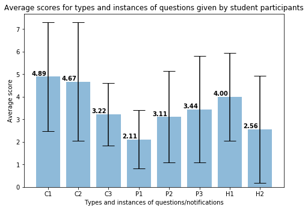

```python
fig = plt.figure()
ax = fig.add_axes([0,0,1,1])
ax.bar(labels,scores_s, yerr=stds_s,  align='center', alpha=0.5, ecolor='black', capsize=10)
for i, v in enumerate(scores_s):
    ax.text(i-.55, v + .05, str( "%.2f" % v), fontweight='bold')
ax.set_ylabel("Average score")
ax.set_xlabel("Types and instances of questions/notifications")
ax.set_title("Average scores for types and instances of questions given by student participants")
plt.show()
```

You can see clearly that for the students, on average, C1 is experienced most relevant while P1 is experienced least relevant. Now let us see what happens if we cluster all instances of the types together:

- C:= {C1,C2,C3};
- P:= {P1,P2,P3};
- H:= {H1,H2}

Obviously, we need to average that out because of the number of instance differences.

```python
# scores of participants with the following order: sum of {c1,c2,c3}; sum of {p1,p2,p3}; sum of {h1,h2}
scores_s_cph = [0,0,0]

# we calculate the standard deviations for C, P, H
stds_s_cph = [scores_s[0:3].std(), scores_s[3:6].std(), scores_s[6:8].std()]
```

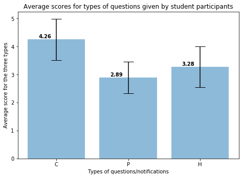

```python
for i in range(0,N):
    # if type is instance of C
    if i<3:
        j=3
        k=0
    # if type is instance of P
    elif i<6:
        j=3
        k=1
    # if type is instance of H
    else:
        j=2
        k=2
    scores_s_cph[k] += scores_s[i]/j

fig = plt.figure()
ax = fig.add_axes([0,0,1,1])
ax.bar(labels_CPH, scores_s_cph, yerr=stds_s_cph,  align='center', alpha=0.5, ecolor='black', capsize=10)
for i, v in enumerate(scores_s_cph):
    ax.text(i-.25, v + .05, str( "%.2f" % v), fontweight='bold')
ax.set_ylabel("Average score for the three types")
ax.set_xlabel("Types of questions/notifications")
ax.set_title("Average scores for types of questions given by student participants")
plt.show()
```

Here we can see that on average, students preferred type C over H and P with a relative large difference.

### 1.1.2 Relevance ranked by policemen

Now let us do the same for the actual experiment with the policemen. We begin again by making a bar plot of the different instances.

```python
# scores of police participants with the following order: c1,c2,c3,p1,p2,p3,h1,h2
scores_p = np.array([])

# standard deviations across police participants
stds_p = []

# for each question
for i in range(0,N):
    # append the standard deviation across police participants of every type
    stds_p.append(police[:,i].std())

    # append the average score of police participants of every type
    scores_p = np.append(scores_p, np.average(police[:,i]))
```

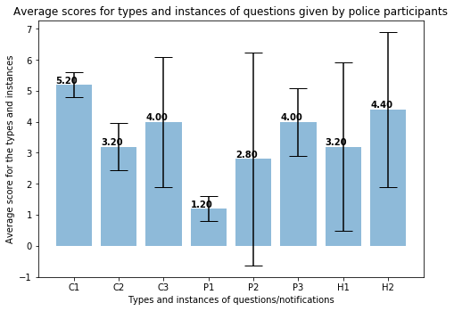

```python
fig = plt.figure()
ax = fig.add_axes([0,0,1,1])
ax.bar(labels,scores_p, yerr=stds_p,  align='center', alpha=0.5, ecolor='black', capsize=10)
for i, v in enumerate(scores_p):
    ax.text(i-.4, v + .05, str( "%.2f" % v), fontweight='bold')
ax.set_ylabel("Average score for the types and instances")
ax.set_xlabel("Types and instances of questions/notifications")
ax.set_title("Average scores for types and instances of questions given by police participants")
plt.show()
```

Here again, we see that on average C1 has gotten the most points (i.e. 5.2) and is thus found most relevant, while P1 is experienced as least relevant with an average of 1.2 points. There is one participant who motivated this answer by writing: *"I don't think the questions in between make me change my mind. It is of course good to think about certain choices and why you make those choices. But I don't change my mind that quickly."*

Now let us again see what happens if we cluster the instances:

```python
scores_p_cph = [0,0,0]

# we calculate the standard deviations for C, P, H
stds_p_cph = [scores_p[0:3].std(), scores_p[3:6].std(), scores_p[6:8].std()]
print(stds_p_cph)
```

```
[0.8219218670625302, 1.1469767022723503, 0.6000000000000001]
```

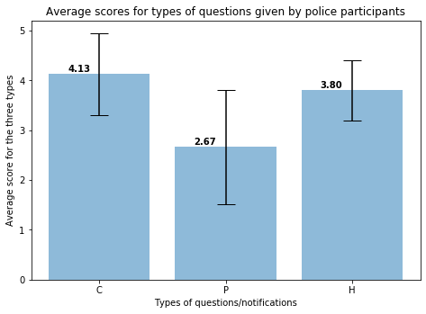

```python
for i in range(0,N):
    # if type is instance of C
    if i<3:
        j=3
        k=0
    # if type is instance of P
    elif i<6:
        j=3
        k=1
    # if type is instance of H
    else:
        j=2
        k=2
    scores_p_cph[k] += scores_p[i]/j

fig = plt.figure()
ax = fig.add_axes([0,0,1,1])
ax.bar(labels_CPH, scores_p_cph, yerr=stds_p_cph,  align='center', alpha=0.5, ecolor='black', capsize=10)
for i, v in enumerate(scores_p_cph):
    ax.text(i-.25, v + .05, str( "%.2f" % v), fontweight='bold')
ax.set_ylabel("Average score for the three types")
ax.set_xlabel("Types of questions/notifications")
ax.set_title("Average scores for types of questions given by police participants")
plt.show()
```

Here we see a similar trend as for the students. We can see that again type C is experienced most relevant and type P is least relevant. However, the difference between C and H is not that large as for the students.

Now, let us see what happens if we combine the results of students and police.

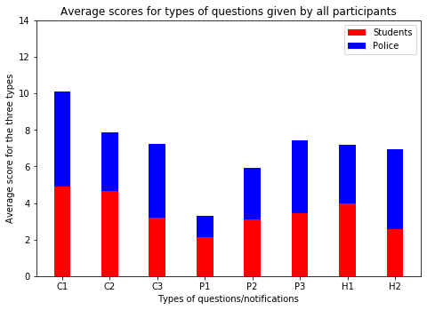

```python
width = 0.35
fig = plt.figure()
ax = fig.add_axes([0,0,1,1])
ax.bar(labels, scores_s, width, color='r')
ax.bar(labels, scores_p, width,bottom=scores_s, color='b')
ax.set_yticks(np.arange(0, 15, 2))
ax.legend(labels=['Students', 'Police'])
ax.set_ylabel("Average score for the three types")
ax.set_xlabel("Types of questions/notifications")
ax.set_title("Average scores for types of questions given by all participants")
plt.show()
```

It is no surprise to see that C1 and P1 are in the same trend as before. The conclusion of this part is that in general C1 (i.e. *"Are you sure about your decision (not) to frisk this person? Why (not)?"*) is most favoured, whereas P1 (i.e. *"Consider that [X] % of all people of the population walking past this spot [...]"* ) is least favoured. On average, for both students and police the Certainty based questions are most relevant and the Population based questions/notifications are most irrelevant.

## 1.2 With what frequency should the RM pose a reflective intervention?

Now, we will analyze the experience about the variable "Frequency". We asked the student participants how they experienced the amount of reflective questions/notifications with 5 possibillities:

- the less the better
- I like less
- neutral
- I like more
- the more the better

This question is included in both surveys (so after both parts the participants were asked this question). Let us see whether there is a difference within and in between participants.

### 1.2.1 The frequency experienced by students

There is no need to understand the cell below.

```python
# --- STUDENTS ---
# divide the data into the three parts
s_surveyA = sps[:,1]
s_surveyA_dss = s_dss[:,1]
s_surveyA_no_dss = s_no_dss[:,1]

s_surveyB = sps[:,0]
s_surveyB_dss = s_dss[:,0]
s_surveyB_no_dss = s_no_dss[:,0]

s_surveyC = sps[:,2]
s_surveyC_dss = s_dss[:,2]
s_surveyC_no_dss = s_no_dss[:,2]

# --- POLICE ---
# divide the data into the two parts
p_surveyA = pps[:,1]
p_surveyA_dss = p_dss[:,1]
p_surveyA_no_dss = p_no_dss[:,1]

p_surveyB = pps[:,0]
p_surveyB_dss = p_dss[:,0]
p_surveyB_no_dss = p_no_dss[:,0]
```

#### Text

First, we will look at the data of the pilot experiment with the students. Note that 'sp' indicates that it is about a student participant and the number refers to the particular participant. In column 1 the responses after part A are shown, whereas in column 2 the responses after part B are shown.

```python
statements(3, participant='students')
```

```
>>>
Survey Question: ' How do you experience the amount of reflective questions and notifications?

Participants    Survey part A         Survey part B
--------------  --------------------  --------------------
sp0 (B->A)      I like more;          I like more;
sp1 (B->A)      The more the better;  The more the better;
sp2 (A->B)      Neutral;              I like more;
sp3 (B->A)      I like more;          I like more;
sp4 (B->A)      Neutral;              Neutral;
sp5 (A->B)      I like more;          Neutral;
sp6 (A->B)      Neutral;              Neutral;
sp7 (A->B)      Neutral;              I like more;
sp8 (A->B)      I like more;          Neutral;
```

Within subjects there are some changes: a few participant switched from "I like more" to "Neutral" and vice versa.

In general, I think we can conclude that our participants did tend to have a positive experience with the RM interventions in this setup.

### 1.2.2 The frequency experienced by police

Now, we will look at the data of the actual experiment.

For the policemen we let go of the two middle options and changed it into a 3-point Likertscale:

- the less the better
- neutral
- the more the better

```python
statements(3)
```

```
>>>
Survey Question: ' How do you experience the amount of reflective questions and notifications?

Participants    Survey part A         Survey part B
--------------  --------------------  --------------------
pp0 (B->A)      Neutral;              The less the better;
pp1 (B->A)      Neutral;              Neutral;
pp2 (B->A)      The more the better;  The more the better;
pp3 (A->B)      The more the better;  The more the better;
pp4 (A->B)      The more the better;  The more the better;
```

Within subjects there is only one change: one participant switched from "The less the better" to "Neutral". He also motivated his first answer with *"My basic training taught me not to deviate too much from your first thought. We often have to make quick decisions in our work."*, while he motivated his second answer with *"Sometimes it seemed like other questions that I had to think about, plus I was a little less sure if I needed to check on someone."*.

Another participant motivated his "The more the better" answer with *"In this way you get a more specific answer."*

In between subjects, there is not much variation. Participants either chose the more the better or neutral. Only one of them chose the less the better, as explained above.

In general, I think we can conclude that our participants did tend to have a positive experience with the questions in this setup.

## 1.3 Does the experience of interacting with a DSS influence the experience of the RM?

The experience of the RM is measured by the level of quality of the reflective questions and notifications and the level of feeling criticized by the reflective questions and notifications of the participant. So statement 6 and 7 cover this question. First we will look at statement 6.

### 1.3.1 Quality of reflective interventions indicated by students

The answers given are ranked with one of the following answers:

- very bad
- bad
- neutral
- good
- very good

```python
statements(5,participant='students')
```

```
>>>
Survey Question: ' How do you experience the quality of the reflective questions and notifications?

Participants    Survey part A    Survey part B
--------------  ---------------  ---------------
sp0 (B->A)      Good;            Good;
sp1 (B->A)      Very good;       Very good;
sp2 (A->B)      Good;            Bad;
sp3 (B->A)      Neutral;         Good;
sp4 (B->A)      Good;            Good;
sp5 (A->B)      Good;            Neutral;
sp6 (A->B)      Neutral;         Neutral;
sp7 (A->B)      Neutral;         Bad;
sp8 (A->B)      Bad;             Bad;
```

#### Analaysis

In general, they tend to be positive towards the quality.

Now we only look at the participants who were (falsely) informed about the DSS:

```python
statements(5, participant='students', dss=1)
```

```
>>>  Informed about the DSS
Survey Question: ' How do you experience the quality of the reflective questions and notifications?

Participants    Survey part A    Survey part B
--------------  ---------------  ---------------
sp6 (A->B)      Neutral;         Neutral;
sp7 (A->B)      Neutral;         Bad;
sp3 (B->A)      Neutral;         Good;
sp0 (B->A)      Good;            Good;
```

#### Analysis

If we look at just the ratings, we can conclude that the quality can be improved, but in general they did not think it was bad.

When we look at the comments given by the participants (see excel sheet), we see that some interventions are experienced as 'a bit vague' (p3 - part A) or they indicate that the interventions 'don't have much influence' (p0 - part A).

Below, we do the same for the participants NOT informed about the DSS.

```python
statements(5, participant='students', dss=2)
```

```
>>>  NOT informed about the dss
Survey Question: ' How do you experience the quality of the reflective questions and notifications?

Participants    Survey part A    Survey part B
--------------  ---------------  ---------------
sp2 (A->B)      Good;            Bad;
sp5 (A->B)      Good;            Neutral;
sp8 (A->B)      Bad;             Bad;
sp1 (B->A)      Very good;       Very good;
sp4 (B->A)      Good;            Good;
```

#### Analysis

Here we see a somewhat more negative experience after part B then after part A.

Looking at the comments, we see some interesting insights: While some participant indicated: *'I think the reflective questions and notifications are very fitting.'* (p4 - part A); and *'The notifications are very good because they really give you insight into your choices, the questions are also good, but I can imagine that most people already ask these themselves.'* (p5 - part A). Others were more negative: *'I don't care about the female to male ratio of frisking'* (p2 - part B); and *'It seems to be just random statistics that have nothing to do with the person I may or may not want to frisk.'* (p8 - part B).

Now, we will look at a bar plot in which we can more easily see the difference between being informed about the DSS vs being uninformed about it.

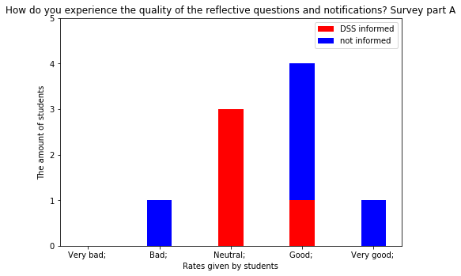

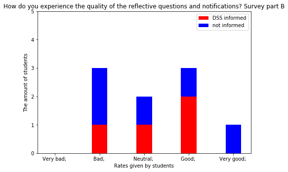

```python
statement(5, participant='students')
```

#### Analysis

We do not see much difference between the informed condition and the uninformed condition.

### 1.3.2 Quality of reflective interventions indicated by police

```python
statements(5,dss=1)
```

```
>>>  Informed about the DSS
Survey Question: ' How do you experience the quality of the reflective questions and notifications?

Participants    Survey part A    Survey part B
--------------  ---------------  ---------------
pp3 (A->B)      Good;            Good;
pp2 (B->A)      Good;            Very good;
pp1 (B->A)      Good;            Good;
```

#### Analysis

Now, we look at the uninformed condition:

```python
statements(5,dss=2)
```

```
>>>  NOT informed about the dss
Survey Question: ' How do you experience the quality of the reflective questions and notifications?

Participants    Survey part A    Survey part B
--------------  ---------------  ---------------
pp0 (B->A)      Good;            Bad;
pp4 (A->B)      Neutral;         Neutral;
```

#### Analysis

The answers here are a bit more negative. One participant switched from 'bad' after part B to 'good' after part A. If we look at the comment this participant gave, we see the reason. Motivating "Bad", he wrote: *"It does not interest me that much. I think a person is suspicious or not, then I don't think about percentages or anything like that"* . This can explain the bad experience with the Population based questions, which are all about percentages. However, motivating "Good", he wrote: *"The questions made me think a little more this time."* Which indicates that he might have experienced a change in between the blocks.

Now, up to the bar plot.

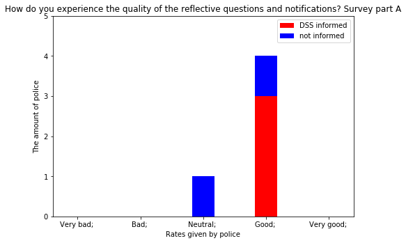

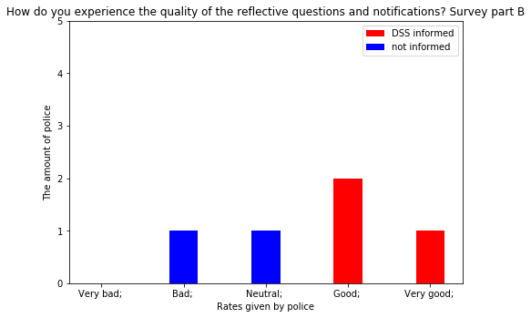

```python
statement(5)
```

We have way too few participants to draw a firm conclusion. Though, when imagined that this pattern is consistent, this may indicate a relationship between the story you tell the participant and the experienced quality of the reflective interventions. We suggest further research into this.

### 1.3.3 Criticism of reflective intervention indicated by students

Remember that we also include the indicated level of experienced criticism.

First again, informed about the DSS.

```python
statements(6, participant='students',dss=1)
```

```
>>>  Informed about the DSS
Survey Question: ' I felt criticized by the reflective questions and notifications

Participants    Survey part A       Survey part B
--------------  ------------------  ------------------
sp6 (A->B)      Neutral;            Neutral;
sp7 (A->B)      Agree;              Neutral;
sp3 (B->A)      Strongly disagree;  Strongly disagree;
sp0 (B->A)      Neutral;            Agree;
```

#### Analysis

The spread is large here, it really differs per participant.

Only one participant motivated the given answers 'Agree' to 'Neutral'. In the survey after part B the motivation was: *'A little bit, which I also thought was funny. It shook me awake for a while that I do have a certain bias myself.'* (p0 - part B), while after part A, it was: *'This time less than last time. But it does keep you sharp.'* (p0 - part A)

Now, uninformed about the DSS:

```python
statements(6, participant='students', dss=2)
```

```
>>>  NOT informed about the dss
Survey Question: ' I felt criticized by the reflective questions and notifications

Participants    Survey part A       Survey part B
--------------  ------------------  ------------------
sp2 (A->B)      Strongly agree;     Strongly agree;
sp5 (A->B)      Neutral;            Neutral;
sp8 (A->B)      Strongly disagree;  Strongly disagree;
sp1 (B->A)      Strongly disagree;  Strongly disagree;
sp4 (B->A)      Disagree;           Disagree;
```

#### Analysis

There is no difference between the two parts. They all stick with their first indication. Also, they generally do not feel criticized.

One participant motivated both his answers with *'The notifications I received were very much in line with what I thought I had answered so I was not surprised by them.'* (p4 - part A&B), whereas other do feel criticized, indicating: *'I especially felt criticized by the notifications, because they almost seem to assume that I am biased for, for example, ethnicity or age. I probably am too, but that's not very nice to hear.'* (p5 - part A). We even got some insight in the different types of interventions: *'I don't care about ratio's of my own work, only statistical reminders of who is most likely to have a weapon'* (p2 - part B).

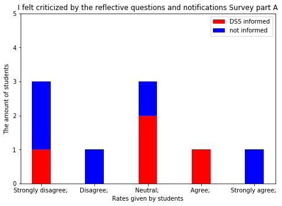

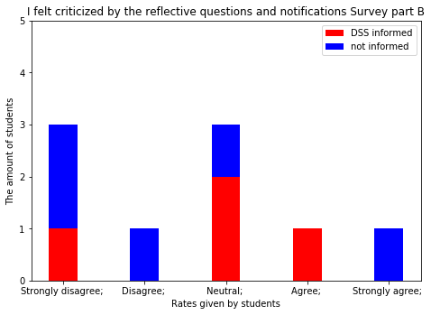

```python
statement(6, participant='students')
```

#### Analysis

We see no difference between part A and B. We also see no noticeable difference between the informed or the uninformed condition.

### 1.3.4 Criticism of reflective intervention indicated by police

```python
statements(6, dss=1)
```

```
>>>  Informed about the DSS
Survey Question: ' I felt criticized by the reflective questions and notifications

Participants    Survey part A       Survey part B
--------------  ------------------  ------------------
pp3 (A->B)      Strongly disagree;  Strongly disagree;
pp2 (B->A)      Strongly disagree;  Strongly disagree;
pp1 (B->A)      Disagree;           Strongly disagree;
```

#### Analysis

We clearly see that none of them felt criticized by the reflective interventions.

```python
statements(6, dss=2)
```

```
>>>  NOT informed about the dss
Survey Question: ' I felt criticized by the reflective questions and notifications

Participants    Survey part A       Survey part B
--------------  ------------------  ------------------
pp0 (B->A)      Disagree;           Disagree;
pp4 (A->B)      Strongly disagree;  Strongly disagree;
```

#### Analysis

Also here, no one felt criticized.

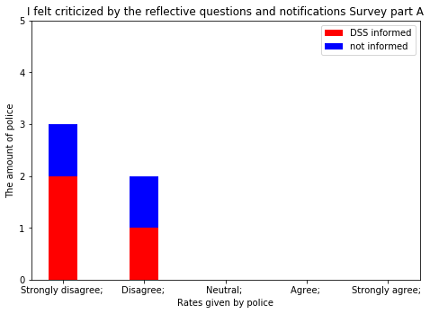

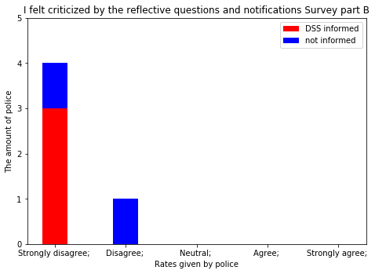

```python
statement(6)
```

We see no indication of any relation between the informed and uninformed condition. However, due to the number of participants and the similarity of the data, this is no firm conclusion. To be able to really say anything meaningful about this, we suggest further research.

# 2. Load the application data

Now we will load the application data. It is not needed to understand the code cells.

```python
# Two functions we need later on
def yesno(a):
    s=np.array([])
    for i in a:
        if i==0:
            s=np.append(s,"No")
        elif i==1:
            s=np.append(s,"Yes")
        elif i==2:
            s=np.append(s,"Idk")
    return s

def toStr(a):
    b=np.array([])
    for i in a:
        s=''
        for j in i:
            if j>0:
                s+=" "
            s+=str(j) +" & "
        b=np.append(b,s[0:len(s)-3])
    return b
```

```python
# frisk or not
d_p0=np.array([1,0,1,1,0,1,0,1,0,0,1,1,0,1,0,1,0,0,0,0])
d_p1=np.array([0,0,0,0,0,1,0,1,0,0,0,1,0,0,0,1,0,0,0,0])
d_p2=np.array([2,1,0,0,1,1,1,0,0,1,0,1,1,1,1,1,0,0,1,0])
d_p3=np.array([0,0,0,0,0,1,0,0,0,0,2,1,0,0,0,2,0,0,0,0])
d_p4=np.array([0,0,0,1,1,1,0,1,0,0,1,1,1,0,0,1,1,0,0,1])
```

## 2.1 Visualization of the decision of participants whether or not they want to frisk

In the next cell, we will visualize the first part of the data. This contains the answers of all participants of all cases. The columns represent the participants, whereas the rows indicate the case. Although the participants have seen a different order of the cases, we ordered them in such a way that for every row it holds that it was the same case for all participants.

However, this automatically implies that for some participants case 0 is not the first case they saw (but case 8 was their first, then uptil 19 and then they saw case 0-7). This holds for participant 0, 1 and 2. Participant 3 and 4 did have case 0 as their first case uptil 19.

```python
d=np.transpose(np.array([yesno(d_p0),yesno(d_p1),yesno(d_p2),yesno(d_p3),yesno(d_p4)]))
df_frisk=pd.DataFrame(data=d, columns=["p"+str(i) for i in range(5)])
df_frisk
```

|  | p0 | p1 | p2 | p3 | p4 |
| --- | --- | --- | --- | --- | --- |
| 0 | Yes | No | Idk | No | No |
| 1 | No | No | Yes | No | No |
| 2 | Yes | No | No | No | No |
| 3 | Yes | No | No | No | Yes |
| 4 | No | No | Yes | No | Yes |
| 5 | Yes | Yes | Yes | Yes | Yes |
| 6 | No | No | Yes | No | No |
| 7 | Yes | Yes | No | No | Yes |
| 8 | No | No | No | No | No |
| 9 | No | No | Yes | No | No |
| 10 | Yes | No | No | Idk | Yes |
| 11 | Yes | Yes | Yes | Yes | Yes |
| 12 | No | No | Yes | No | Yes |
| 13 | Yes | No | Yes | No | No |
| 14 | No | No | Yes | No | No |
| 15 | Yes | Yes | Yes | Idk | Yes |
| 16 | No | No | No | No | Yes |
| 17 | No | No | No | No | No |
| 18 | No | No | Yes | No | No |
| 19 | No | No | No | No | Yes |

### 2.1.1 Analysis

We can see that there is a large variety in within as well as in between subjects. Let's try to filter out the ones they did agree upon in between subject.

```python
for word in {'Yes', 'No'}:
    samesies = df_frisk[(df_frisk['p0'] == word) & (df_frisk['p1'] == word) & (df_frisk['p2'] == word) & (df_frisk['p3'] == word) & (df_frisk['p4'] == word)]
    print(samesies)
```

```
    p0  p1  p2  p3  p4
8   No  No  No  No  No
17  No  No  No  No  No
     p0   p1   p2   p3   p4
5   Yes  Yes  Yes  Yes  Yes
11  Yes  Yes  Yes  Yes  Yes
```

We can see that for cases 8, 17, 5 and 11 they all had the same answer. We will remember these cases and check the motivations later.

First, we will visualize how many times the participants decided (not) to frisk.

```python
amounts = pd.DataFrame(
    {'Yes': [len(df_frisk[(df_frisk['p'+str(i)] == 'Yes')]) for i in range(5)],
     'No': [len(df_frisk[(df_frisk['p'+str(i)] == 'No')]) for i in range(5)],
     'Idk': [len(df_frisk[(df_frisk['p'+str(i)] == 'Idk')]) for i in range(5)]},
     index=['p' +str(i) for i in range(5)])
amounts
```

|  | Yes | No | Idk |
| --- | --- | --- | --- |
| p0 | 9 | 11 | 0 |
| p1 | 4 | 16 | 0 |
| p2 | 11 | 8 | 1 |
| p3 | 2 | 16 | 2 |
| p4 | 10 | 10 | 0 |

The most outstanding participant is p3. He decided to only frisk two individuals, namely individual 5 and 11. These are also the two cases each participant decided to frisk.

## 2.2 Cluster motivations

In order to understand the decisions of the participants, we have to dive deeper into the motivations behind the decisions whether to frisk or not. After eye-balling the motivations of the possible answers participants gave, we divided it into 6 clusters why people chose to frisk an individual; and 5 distinct clusters why people chose not to frisk an individual. In some cases, participants gave multiple reasons why they wanted to (not) frisk a particular individual. The 6 clusters with reasons to frisk are:

- 1) distinct pace
- 2) individual is alone
- 3) suspicious focus
- 4) distinct use of -or attention towards- accessoires
- 5) deviant behaviour
- 6) other, e.g. information told upfront; information told during experiment; gut feeling; it will not hurt to do it; etc.

Whereas the clusters with reasons NOT to frisk are:

- -1) not the type to be carrying a weapon
- -2) factual description of the situation
- -3) no deviant behaviour
- -4) cannot find a specific reason to frisk
- -5) individual seems to be goal-oriented

Because the motivation is optional, sometimes a motivation is not given, then we label it with:

- 0) no reason is given

```python
# clustered motivation
cm_p0=np.array([[6],[-1],[4,6],[4],[-1],[5],[-4,-5],[1,4,5],[-5],[-4],[5],[5],[-4,-5],[3,6],[-4],[3,5],[-4],[-4,-5],[-4],[-4]])
cm_p1=np.array([[0],[0],[0],[0],[0],[5],[0],[3],[0],[0],[0],[0],[0],[0],[0],[3,5],[0],[0],[0],[0]])
cm_p2=np.array([[0],[-2],[-3],[0],[3,4],[5],[3],[-3],[-3],[5,1],[-3],[5,4,1,2],[5,4],[5,4,3,2],[5],[5],[-3],[-3],[3,4],[-3]])
cm_p3=np.array([[-4],[-2],[-4],[0],[0],[3],[-3],[-3],[-3],[0],[5],[3],[-3],[0],[-1],[5],[-3],[0],[-3],[-2]])
cm_p4=np.array([[-2,-3],[-2,-3],[-5],[1,4],[3,5],[5,1],[-5,-3],[4,1,5],[-3],[-3],[5],[4],[4],[-3],[-4,-2],[3,5],[1,3],[-3,-5],[-3],[4,6]])

# rm question / notification
rmq=np.array(['','P3','','C2','H2','C3','P3','H2','C2','C3','C1','C3','P1','P1','P3','P1','H2','H2','H2','H2' ])

# answer rm question
a_rmq=np.array([[0,0,0,0,0],[0,0,0,0,0],[0,0,0,0,0],[4,1,3,5,4],[0,0,0,0,0],yesno([1,1,1,2,1]),[0,0,0,0,0],[0,0,0,0,0],[1,1,1,5,3],yesno([0,1,1,2,0]),yesno([1,0,1,1,1]),[5,4,1,5,4],[0,0,0,0,0],[0,0,0,0,0],[0,0,0,0,0],[0,0,0,0,0],[0,0,0,0,0],[0,0,0,0,0],[0,0,0,0,0],[0,0,0,0,0]])
```

### 2.2.1 Visualizing the motivations

Here, we will visualize the motivations together with the decisions.

```python
cm=np.transpose(np.array([toStr(cm_p0),toStr(cm_p1),toStr(cm_p2),toStr(cm_p3),toStr(cm_p4)]))

for i in range(5):
    df_frisk.insert(2*i+1, "Motivation " +str(i), cm[:,i])

df_frisk
```

|  | p0 | Motivation 0 | p1 | Motivation 1 | p2 | Motivation 2 | p3 | Motivation 3 | p4 | Motivation 4 |
| --- | --- | --- | --- | --- | --- | --- | --- | --- | --- | --- |
| 0 | Yes | 6 | No | 0 | Idk | 0 | No | -4 | No | -2 & -3 |
| 1 | No | -1 | No | 0 | Yes | -2 | No | -2 | No | -2 & -3 |
| 2 | Yes | 4 & 6 | No | 0 | No | -3 | No | -4 | No | -5 |
| 3 | Yes | 4 | No | 0 | No | 0 | No | 0 | Yes | 1 & 4 |
| 4 | No | -1 | No | 0 | Yes | 3 & 4 | No | 0 | Yes | 3 & 5 |
| 5 | Yes | 5 | Yes | 5 | Yes | 5 | Yes | 3 | Yes | 5 & 1 |
| 6 | No | -4 & -5 | No | 0 | Yes | 3 | No | -3 | No | -5 & -3 |
| 7 | Yes | 1 & 4 & 5 | Yes | 3 | No | -3 | No | -3 | Yes | 4 & 1 & 5 |
| 8 | No | -5 | No | 0 | No | -3 | No | -3 | No | -3 |
| 9 | No | -4 | No | 0 | Yes | 5 & 1 | No | 0 | No | -3 |
| 10 | Yes | 5 | No | 0 | No | -3 | Idk | 5 | Yes | 5 |
| 11 | Yes | 5 | Yes | 0 | Yes | 5 & 4 & 1 & 2 | Yes | 3 | Yes | 4 |
| 12 | No | -4 & -5 | No | 0 | Yes | 5 & 4 | No | -3 | Yes | 4 |
| 13 | Yes | 3 & 6 | No | 0 | Yes | 5 & 4 & 3 & 2 | No | 0 | No | -3 |
| 14 | No | -4 | No | 0 | Yes | 5 | No | -1 | No | -4 & -2 |
| 15 | Yes | 3 & 5 | Yes | 3 & 5 | Yes | 5 | Idk | 5 | Yes | 3 & 5 |
| 16 | No | -4 | No | 0 | No | -3 | No | -3 | Yes | 1 & 3 |
| 17 | No | -4 & -5 | No | 0 | No | -3 | No | 0 | No | -3 & -5 |
| 18 | No | -4 | No | 0 | Yes | 3 & 4 | No | -3 | No | -3 |
| 19 | No | -4 | No | 0 | No | -3 | No | -2 | Yes | 4 & 6 |

### 2.2.2 Analysis

We immediately see a distinction in participants. Participant 0, 2 and 4 are very consistent and elaborate in their motivations. Participant 3 is mediocre in motivating and participant 1 (p1) was not very interested in giving reasons why not to frisk an individual. However, in cases where he did frisk someone he usually gave a reason why.

It also clearly stands out that p1 only had 2 reasons: a suspicious focus (3) and distinct behaviour (5). Now let us look at some details. Again, you can ignore the code below.

```python
def motivation_of_cluster(df,i,p=-1):
    i=round(i)
    if i>0:
        j =" " + str(i)
        if p!=-1:
            return df.loc[df["Motivation " + str(p)].str.contains(j)]
    else:
        j =str(i)
        if p!=-1:
            return df.loc[df["Motivation " + str(p)].str.contains(j)]
    return df.loc[df["Motivation 0"].str.contains(j) |
                   df["Motivation 1"].str.contains(j) |
                   df["Motivation 2"].str.contains(j) |
                   df["Motivation 3"].str.contains(j) |
                   df["Motivation 4"].str.contains(j)]
```

### 2.2.3 More detailed analysis

Here, you are able to vary yourself between motivations. You can set 'i' as a number of the set {-5,-4, ... ,5,6} and the output will be all cases where that number is given as a motivation. To remind you, we list the numbers again below.

- 1) distinct pace
- 2) individual is alone
- 3) suspicious focus
- 4) distinct use of -or attention towards- accessoires
- 5) distinct behaviour
- 6) other, e.g. information told upfront; information told during experiment; gut feeling; it will not hurt to do it; etc.

Whereas the clusters with reasons NOT to frisk are:

- -1) no type for carrying a weapon
- -2) factual explanation of the situation
- -3) no abnormality in behaviour
- -4) no potential specific reason to frisk
- -5) individual seems to be goal-oriented

Because the motivation is optional, sometimes a motivation is not given, then we label it with:

- 0) no reason is given

```python
i = 1

mot = motivation_of_cluster(df_frisk, i)
mot
```

|  | p0 | Motivation 0 | p1 | Motivation 1 | p2 | Motivation 2 | p3 | Motivation 3 | p4 | Motivation 4 |
| --- | --- | --- | --- | --- | --- | --- | --- | --- | --- | --- |
| 3 | Yes | 4 | No | 0 | No | 0 | No | 0 | Yes | 1 & 4 |
| 5 | Yes | 5 | Yes | 5 | Yes | 5 | Yes | 3 | Yes | 5 & 1 |
| 7 | Yes | 1 & 4 & 5 | Yes | 3 | No | -3 | No | -3 | Yes | 4 & 1 & 5 |
| 9 | No | -4 | No | 0 | Yes | 5 & 1 | No | 0 | No | -3 |
| 11 | Yes | 5 | Yes | 0 | Yes | 5 & 4 & 1 & 2 | Yes | 3 | Yes | 4 |
| 16 | No | -4 | No | 0 | No | -3 | No | -3 | Yes | 1 & 3 |

In the next bit of code, we show the reasons per participant where the columns represent the participants and the rows represent the cluster labels. We also added a 'total' in which you can see how many times this is a reason for all participants summed up.

```python
occ=[]
for i in range(-5,7):
    p=np.array([])
    for j in range(5):
        p=np.append(p, "%.f" % len(motivation_of_cluster(df_frisk,i,j)))
    occ.append(p)
occ = np.array(occ)
total = np.array([[sum([int(i) for i in occ[j]]) for j in range(len(occ))]])
occ = np.concatenate((occ.T, total))
pd.DataFrame(data=occ.T, columns=["p" +str(0),"p" +str(1),"p" +str(2),"p" +str(3),"p" +str(4),"Total"],
             index=[[i for i in range(-5,7)]])
```

|  | p0 | p1 | p2 | p3 | p4 | Total |
| --- | --- | --- | --- | --- | --- | --- |
| -5 | 4 | 0 | 0 | 0 | 3 | 7 |
| -4 | 8 | 0 | 0 | 2 | 1 | 11 |
| -3 | 0 | 0 | 7 | 6 | 8 | 21 |
| -2 | 0 | 0 | 1 | 2 | 3 | 6 |
| -1 | 2 | 0 | 0 | 1 | 0 | 3 |
| 0 | 0 | 17 | 2 | 5 | 0 | 24 |
| 1 | 1 | 0 | 2 | 0 | 4 | 7 |
| 2 | 0 | 0 | 2 | 0 | 0 | 2 |
| 3 | 2 | 2 | 4 | 2 | 3 | 13 |
| 4 | 3 | 0 | 5 | 0 | 5 | 13 |
| 5 | 5 | 2 | 7 | 2 | 5 | 21 |
| 6 | 3 | 0 | 0 | 0 | 1 | 4 |

We see that (next to giving no motivation) 'distinct behaviour' (5) is indicated most of times as the reason to frisk someone. For not frisking someone, 'no abnormality in behaviour' (-3) is indicated most of times. This is obviously in line with how it should be.

### 2.2.4 Coming back at case 5, 8, 11 and 17

Remember that at some point we said we would come back at the cases in which every participant agrees. We will try to line up the motivations in which we may see a pattern.

```python
df_frisk.loc[[5,8,11,17]]
```

|  | p0 | Motivation 0 | p1 | Motivation 1 | p2 | Motivation 2 | p3 | Motivation 3 | p4 | Motivation 4 |
| --- | --- | --- | --- | --- | --- | --- | --- | --- | --- | --- |
| 5 | Yes | 5 | Yes | 5 | Yes | 5 | Yes | 3 | Yes | 5 & 1 |
| 8 | No | -5 | No | 0 | No | -3 | No | -3 | No | -3 |
| 11 | Yes | 5 | Yes | 0 | Yes | 5 & 4 & 1 & 2 | Yes | 3 | Yes | 4 |
| 17 | No | -4 & -5 | No | 0 | No | -3 | No | 0 | No | -3 & -5 |

For the reasons not to frisk, we see no abnormality in behaviour (-3) and indidividual seems to be goal-oriented (-5) as most frequent reasons given.